## Continuous Probability

We earlier explained why when summarizing a list of numeric values, such as heights, it is not useful to construct a distribution that defines a proportion to each possible outcome. Note, for example, that if we measure every single person in a very large population of size $n$ with extremely high precision, because no two people are exactly the same height, we need to assign the proportion $1/n$ to each observed value and attain no useful summary at all. Similarly, when defining probability distributions, it is not useful to assign a very small probability to every single height.

Just like when using distributions to summarize numeric data, it is much more practical to define a function that operates on intervals rather than single values. The standard way of doing this is using the *cumulative distribution function* (CDF).

We previously described the empirical cumulative distribution function (eCDF) as a basic summary of a list of numeric values. As an example, we defined the height distribution for male students. Here we define the vector $x$ to contain the male heights:

```r
library(tidyverse)
library(dslabs)
data(heights)
x <- heights %>% filter(sex == "Male") %>% .$height
```

We defined the empirical distribution function as

```r
F <- function(a){
  mean(x <= a)
}
```

which, for any value `a`, gives the proportion of values in the list `x` that are smaller or equal to `a`.

Note that we have not yet introduced probability. Let’s do this by asking, if I pick one of the male students at random, what is the chance that he is taller than 70.5 inches? Because every student has the same chance of being picked, the answer to this is equivalent to the proportion of students that are taller than 70.5 inches. Using the CDF we obtain an answer by typing:

```r
1 - F(70.5)
```

```
## [1] 0.3633005
```

Once a CDF is defined, we can use this to compute the probability of any subset. For example the probability of a student being between height `a` and height `b` is

```r
F(b)-F(a)
```

Because we can compute the probability for any possible event this way, the cumulative probability function defines the probability distribution for picking a height at random from our vector of heights `x`.

### Theoretical distribution

In the data visualization chapter we introduced the normal distribution as a useful approximation to many naturally occurring distributions, including that of height. The cumulative distribution for the normal distribution is defined by a mathematical formula which in R can be obtained with the function `pnorm`. We say that a random quantity is normally distributed with average `avg` and standard deviation `s` if its probability distribution is defined by

```r
F(a) = pnorm(a, avg, s)
```

This is useful because if we are willing to use the normal approximation for, say, height we don’t need the entire data set to answer questions such as “what is the probability that a randomly selected student is taller then 70.5 inches?”. We just need the average height and standard deviation:

```r
avg <- mean(x)
s   <- sd(x)
1 - pnorm(70.5, avg, s)
```

```
## [1] 0.371369
```

Note that this is pretty close to the exact probability from our dataset, 0.3633005.

### Approximations

The normal distribution is derived mathematically: we do not need data to define it. For practicing data scientists, pretty much everything we do involves data. Data is always, technically speaking, discrete. For example, we could consider our height data categorical with each specific height a unique category. The probability distribution is defined by the proportion of students reporting each height. Here is a plot of that probability distribution:

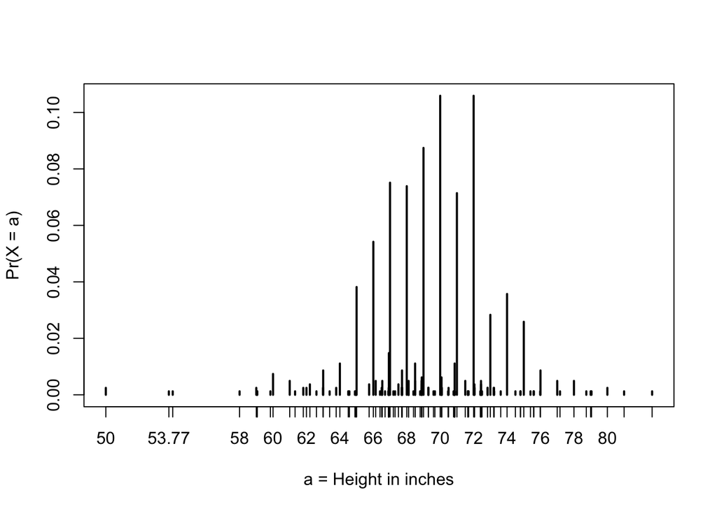

While most students rounded up their heights to the nearest inch, others reported values with more precision.  
For example, one student reported his height to be 69.6850393700787 which is 177 centimeters. The probability assigned to this height is 0.0012315 or 1 in 812. The probability for 70 inches is much higher 0.1059113, but does it really make sense to think of that the probability of being exactly 70 inches is the same as being 69.6850393700787? Clearly it is much more useful for data analytic purposes to treat this outcome as a continuous numeric variable, keeping in mind that very few people, or perhaps none, are exactly 70 inches, and that the reason we get more values at 70 is because people round to the nearest inch.

With continuous distributions the probability of a singular value is not even defined. For example, it does not make sense to ask what is the probability that a normally distributed value is 70. Instead we define probabilities for **intervals**. So we could ask what is the probability that someone is between 69.5 and 70.5 inches?

In cases like height, in which the data is rounded, the normal approximation is particularly useful if we deal with intervals that include exactly one round number. So for example, the normal distribution is useful for approximating the proportion of students reporting between 69.5 and 70.5:

```r
mean(x <= 68.5) - mean(x <= 67.5)
```

```
## [1] 0.114532
```

```r
mean(x <= 69.5) - mean(x <= 68.5)
```

```
## [1] 0.1194581
```

```r
mean(x <= 70.5) - mean(x <= 69.5)
```

```
## [1] 0.1219212
```

Note how close we get with the normal approximation:

```r
pnorm(68.5, avg, s) - pnorm(67.5, avg, s)
```

```
## [1] 0.1031077
```

```r
pnorm(69.5, avg, s) - pnorm(68.5, avg, s)
```

```
## [1] 0.1097121
```

```r
pnorm(70.5, avg, s) - pnorm(69.5, avg, s)
```

```
## [1] 0.1081743
```

However, the approximation is not as useful for other intervals. For example note how the approximation breaks when we try to estimate

```r
mean(x <= 70.9) - mean(x <= 70.1)
```

```
## [1] 0.02216749
```

with

```r
pnorm(70.9, avg, s) - pnorm(70.1, avg, s)
```

```
## [1] 0.08359562
```

In general we call this situation *discretization*. Although the true height distribution is continuous, the reported heights tend to be more common at discrete values, in this case, due to rounding. As long as we are aware of how to deal with this reality, the normal approximation can still be a very useful tool.

### The probability density

For categorical distributions we can define the probability of a category. For example a roll of a die, let’s call it $X$, can be 1,2,3,4,5 or 6. The probability of rolling a 4 is defined as

$$\mbox{Pr}(X=4) = 1/6$$

The CDF can then easily be defend:
$$F(4) = \mbox{Pr}(X\leq 4) = \mbox{Pr}(X = 4) + \mbox{Pr}(X = 3) + \mbox{Pr}(X = 2) + \mbox{Pr}(X = 1)$$

Although for continuous distributions the probability of a single value $\mbox{Pr}(X=x)$ is not defined there is a theoretical definition that has a similar interpretation. The probability density at $x$ is defined as the function $f(a)$ such that

$$F(a) = \mbox{Pr}(X\leq a) = \int_{-\infty}^a f(x)\, dx$$

For those that know Calculus, remember that the integral is related to a sum: it is the sum of bars with widths approximating 0. If you don’t know Calculus you can think of $f(x)$ as a curve for which the area under that curve up to the value $a$ gives you the probability of $X\leq a$.

For example, to use the normal approximation to estimate the probability of someone being taller than 76 inches we use

```r
1 - pnorm(76, avg, s)
```

```
## [1] 0.03206008
```

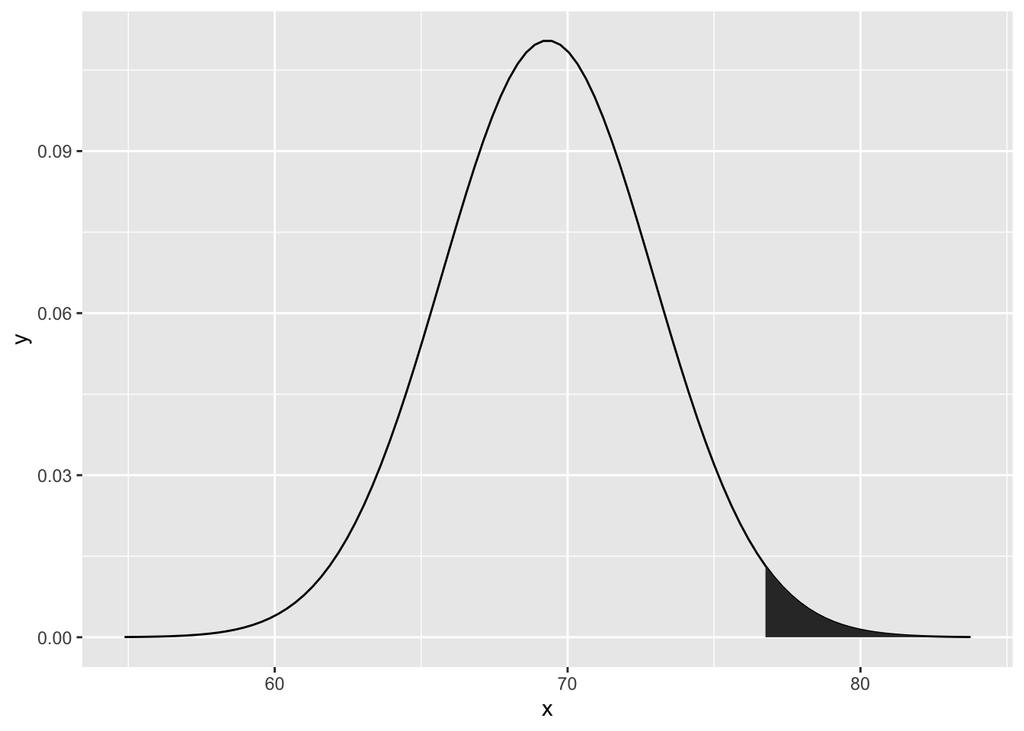

The curve you see is the probability density for the normal distribution. In R we get this using the function `dnorm`.

Although it may not be immediately obvious why knowing about probability densities is useful, understanding this concept will be essential to those wanting to fit models to data for which predefined functions are not available.

### Monte Carlo simulations

R provides functions to generate normally distributed outcomes. Specifically, the `rnorm` function takes three arguments: size, average (defaults to 0), and standard deviation (defaults to 1) and produces random numbers. Here is an example of how we could generate data that looks like our reported heights:

```r
n   <- length(x)
avg <- mean(x)
s   <- sd(x)
simulated_heights <- rnorm(n, avg, s)
```

Not surprisingly the distribution looks normal:

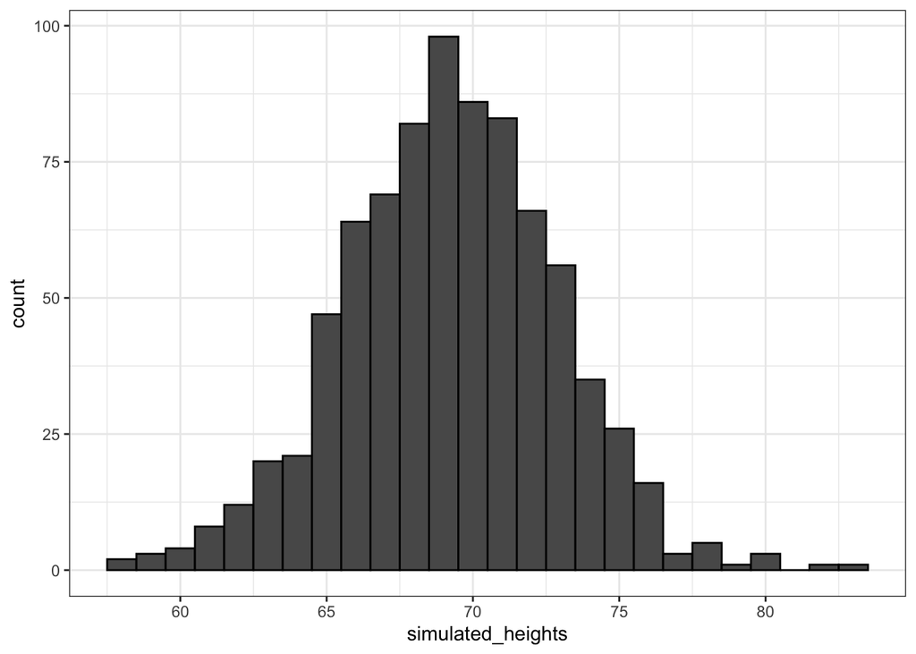

This is one of the most useful functions in R as it will permit us to generate data that mimics natural events and answer questions related to what could happen by chance by running Monte Carlo Simulations.

For example, if we pick 800 males at random, what is the distribution of the tallest person? How rare is a seven foot person? The following Monte Carlo simulation helps us answer that question:

```r
B <- 10000
tallest <- replicate(B, {
  simulated_data <- rnorm(800, avg, s)
  max(simulated_data)
})
```

A seven foot person is quite rare:

```r
mean(tallest >= 7*12)
```

```
## [1] 0.0173
```

Here is the resulting distribution:

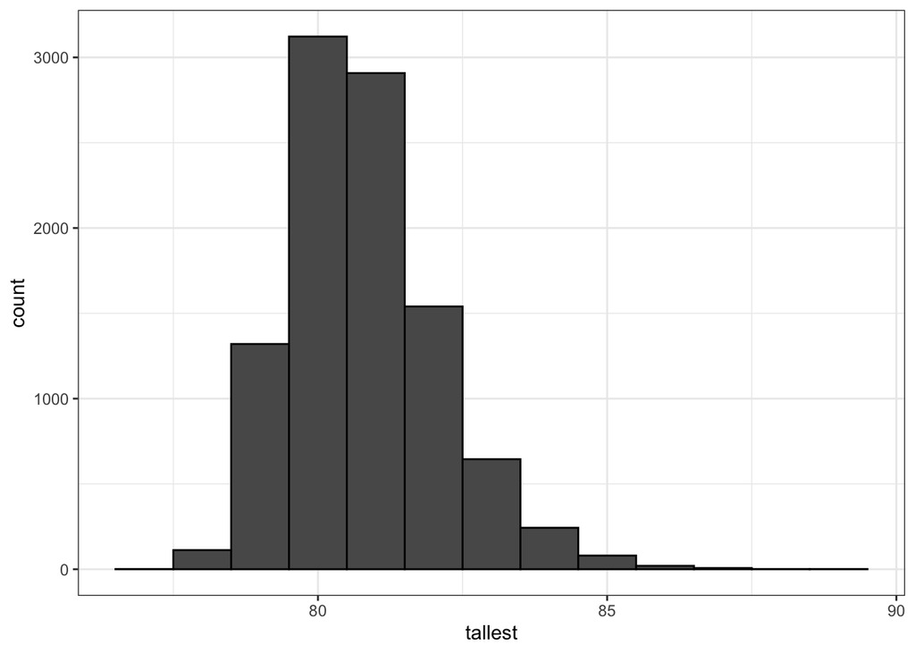

Note that it does not look normal it is skewed to the right.

### Other Continuous Distributions

The normal distribution is not the only useful theoretical distribution. Other continuous distributions that we may encounter are the student-t, chi-squared, exponential, gamma, beta, and beta-binomial. R provides functions to compute the density, the quantiles, the cumulative distribution functions and to generate Monte Carlo simulations. R uses a convention that helps to remember the names. Namely using the letters `d`, `q`, `p` and `r` in front of a shorthand for the distribution. We have already seen the functions `dnorm`, `pnorm` and `rnorm` for the normal distribution. The function `qnorm` gives us the quantiles. For example, we can draw a distribution like this:

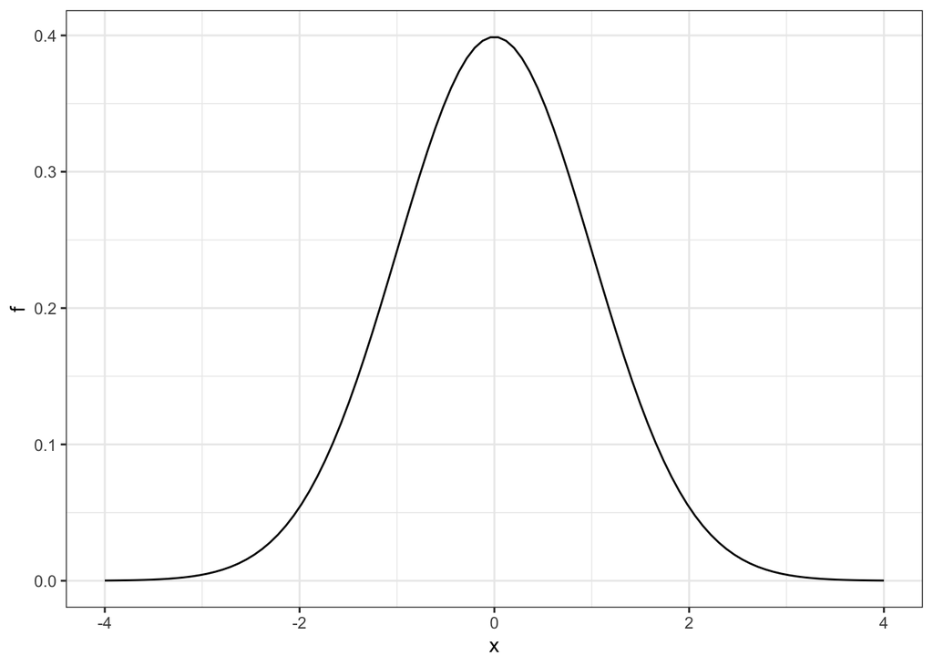

```r
x <- seq(-4, 4, length.out = 100)
data.frame(x, f = dnorm(x)) %>% ggplot(aes(x, f)) + geom_line()
```

For example, for the student-t the shorthand `t` is used so the functions are `dt` for the density, `qt` for the quantiles, `pt` for the cumulative distribution function, and `rt` for Monte Carlo simulations.